# Single cell sequencing of PDX models

## Quality Filters

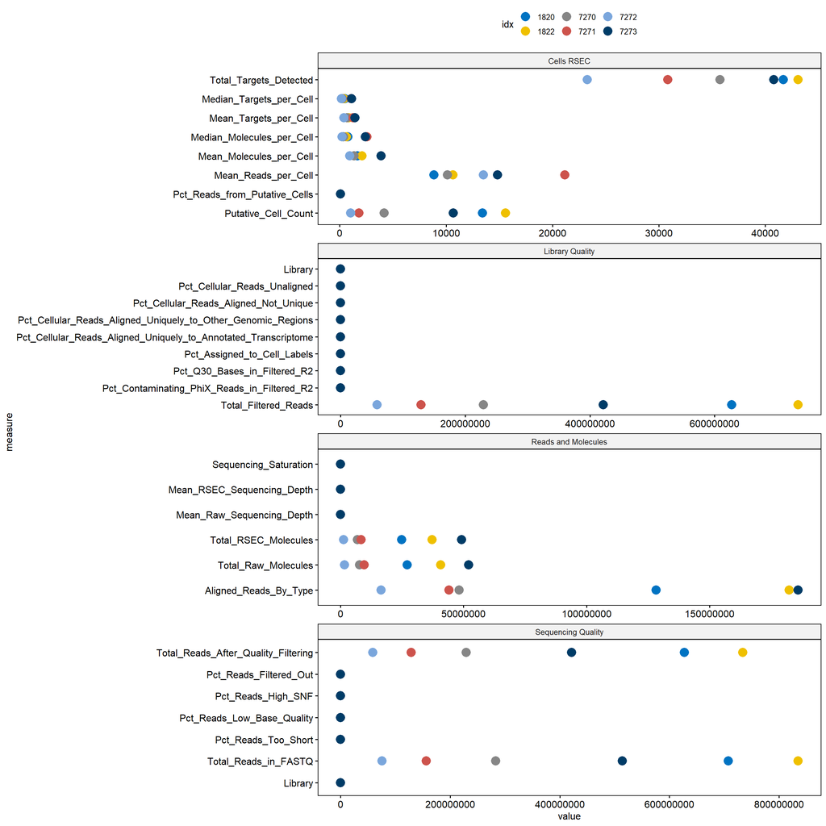

|  | quality | measure | 1820 | 1822 | 7270 | 7271 | 7272 | 7273 |
| --- | --- | --- | --- | --- | --- | --- | --- | --- |
| 1 | Cells RSEC | Putative_Cell_Count | 13408 | 15592 | 4177 | 1805 | 1041 | 10668 |
| 2 | Cells RSEC | Pct_Reads_from_Putative_Cells | 92.62 | 91.04 | 87.97 | 86.7 | 85.62 | 85.06 |
| 3 | Cells RSEC | Mean_Reads_per_Cell | 8862.8 | 10647.57 | 10139.12 | 21153.52 | 13502.6 | 14829.36 |
| 4 | Cells RSEC | Mean_Molecules_per_Cell | 1664.36 | 2100.92 | 1355.07 | 3894.65 | 935.23 | 3888.85 |
| 5 | Cells RSEC | Median_Molecules_per_Cell | 771 | 635 | 373 | 2550 | 227 | 2410.5 |
| 6 | Cells RSEC | Mean_Targets_per_Cell | 733.95 | 871.31 | 679.93 | 1259.68 | 400.04 | 1440.5 |
| 7 | Cells RSEC | Median_Targets_per_Cell | 484 | 397 | 249 | 1101 | 164 | 1128 |
| 8 | Cells RSEC | Total_Targets_Detected | 41704 | 43086 | 35755 | 30840 | 23261 | 40814 |
| 9 | Library Quality | Total_Filtered_Reads | 627376812 | 734020071 | 229012065 | 128943557 | 58549837 | 421304264 |
| 10 | Library Quality | Pct_Contaminating_PhiX_Reads_in_Filtered_R2 | 0 | 0 | 0 | 0 | 0 | 0 |

[output cut: 20 more lines]

## Molecular index statistics

PCR and sequencing errors within UMI sequence generate artifact molecules and contribute to over estimation of molecules. Molecular Index (MI) adjustment identify these artifacts and discard or re-assign them to their original index (from BD slides).

```
# A tibble: 6 x 2
  idx   meanRSEC
  <chr>    <dbl>
1 1820      5.67
2 1822      4.99
3 7270      5.52
4 7271      4.42
5 7272     11.0
6 7273      3.87
```

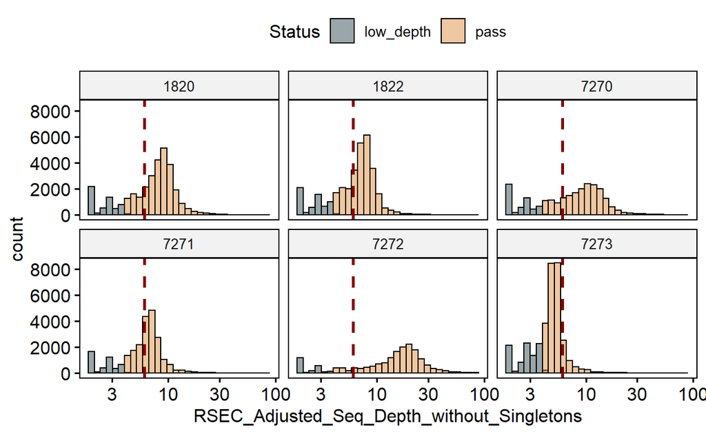

Figure 1: The figure shows the molecular index statistics for the all samples.

In general, this is a two-step process, including RSEC-adjustment and DBEC-adjustment

1. Recursive Substitution Error Correction (RSEC)
- Corrects for MI errors that are derived from sequencing base calls and PCR substitution errors
- Based on edit distance of molecular indices
- Similar method used by most other competitors/academic pipelines
2. Distribution Based Error Correction (DBEC)
- Adjusts for errors derived from library preparation steps or sequencing base deletions.
- Based on distribution of sequencing coverage of molecular indices
- Developed at BD Genomics

Due to the low sequencing depth in our example (see threshold in Figure), DBEC-adjustment was not applied.

# Outline of analysis steps

We use RSEC adjusted molecules from the pipeline at 7bridges as a starting point for the analysis of human single cells and refer to (Luecken and Theis 2019) as a guideline for the analysis of the count matrices.

1. quality control
   1. number of counts per cell
   2. number of genes per cell
   3. number of mitochondrial genes per cell
2. normalization
   1. on cellular counts
   2. on gene level
3. data correction (batch / cell cycle effect …) and integration
   1. regressing out biological effects
   2. regressing out technical effects
   3. integration of multiple samples
4. expression recovery (denoising or imputation)
5. feature selection and dimensionality reduction
6. biological downstream analysis
   1. clustering
   2. pathway analysis
   3. to be discussed …

-> back to top

# Single cell analysis

## quality control

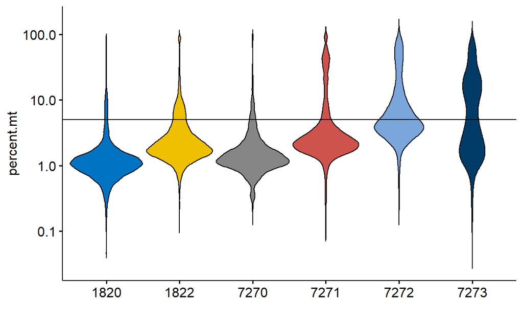

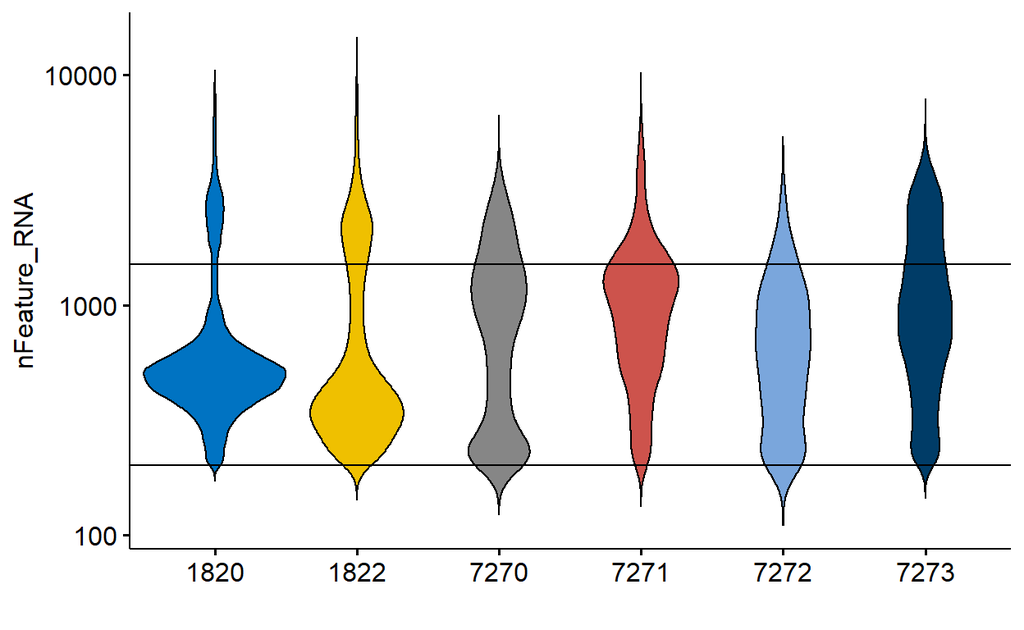

# Go enrichtment analysis

| x |
| --- |
| MT-ATP6 |
| MT-ATP8 |
| MT-CO1 |
| MT-CO2 |
| MT-CO3 |
| MT-CYB |
| MT-ND1 |
| MT-ND2 |
| MT-ND3 |
| MT-ND4 |
| MT-ND4L |
| MT-ND5 |
| MT-ND6 |
| MT-RNR1 |
| MT-RNR2 |
| MT-TA |
| MT-TC |
| MT-TD |
| MT-TE |
| MT-TF |
| MT-TG |
| MT-TH |
| MT-TI |
| MT-TK |
| MT-TL1 |
| MT-TL2 |
| MT-TM |
| MT-TN |
| MT-TP |
| MT-TQ |
| MT-TR |
| MT-TS1 |
| MT-TS2 |
| MT-TT |
| MT-TV |
| MT-TW |
| MT-TY |

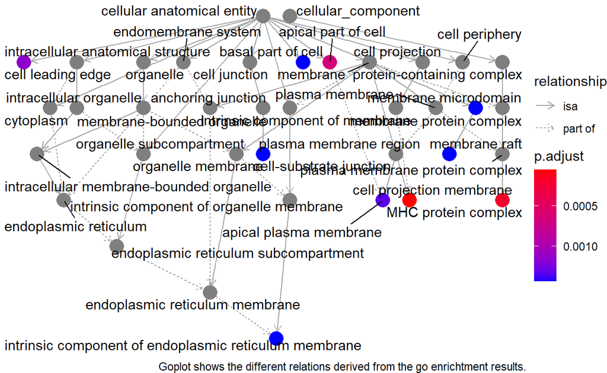

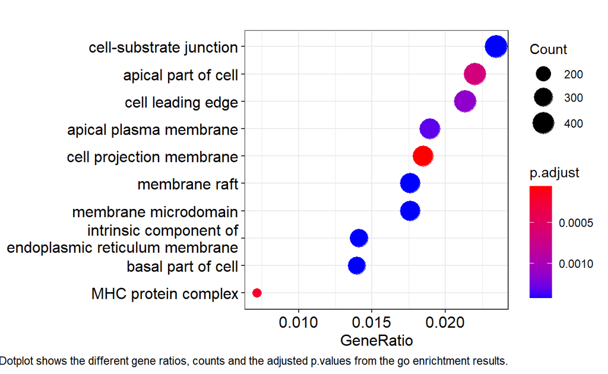

Luecken, Malte D, and Fabian J Theis. 2019. “Current Best Practices in Single‐cell RNA‐seq Analysis: A Tutorial.” *Molecular Systems Biology* 15 (June): e8746. https://doi.org/10.15252/msb.20188746.